# S31: Data Analysis

## Program

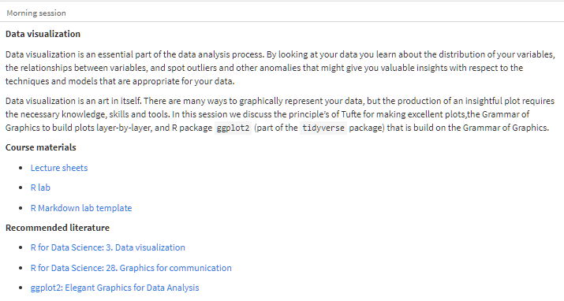

## Content

**Data visualization**

1. Exploratory data analysis
2. Tufte’s Principles of Graphical Excellence
3. Grammar of Graphics
4. Some examples
5. Lab preview

## What’s data visualization?

Communication of data by encoding it as visual objects, i.e.

- dots, lines, bars, etc.

\(~\)

to make data more accessible, understandable and usable.

## Integral part of data science process

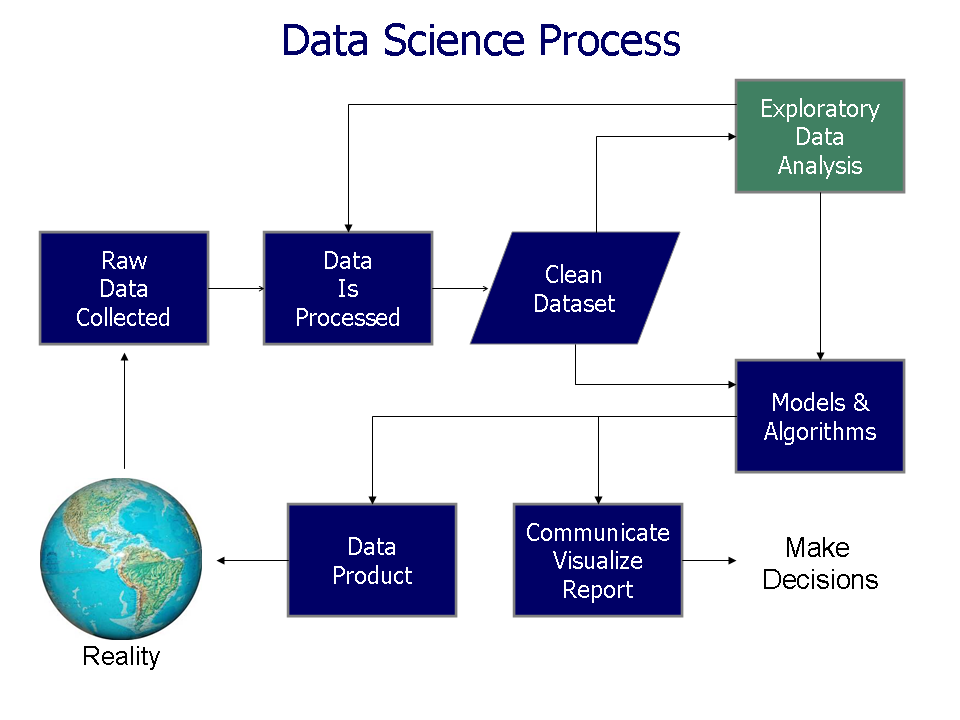

## Exploratory data analysis

Visualize variation and covariation in your data

- discover unexpected patterns in your data
- detect outliers and other anomalies
- understand your data

\(~\)

Get new ideas about your data!

## Early example

The 1854 Soho cholera outbreak was not due to ‘miasma’ (John Snow)

[figure not shown]

## Tufte’s Principles of Graphical Excellence

## Guidelines for representing visual information

“Graphical excellence is that which gives to the viewer the greatest number of ideas in the shortest time with the least ink in the smallest space.” **Edward R. Tufte, The Visual Display of Quantitative Information**

\(~\)

- Proportionality principle
- Maximize data-to-ink ratio
- Omit chart junk

## Proportionality principle

- proportion of ink should be **directly proportional to the numerical quantities** represented.

## Early example

[figure not shown]

## Maximize data-to-ink ratio

- use of colors and text sparsely

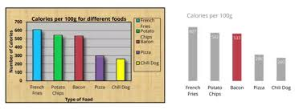

## Omit chart junk

[figure not shown]

## Tufte in practice

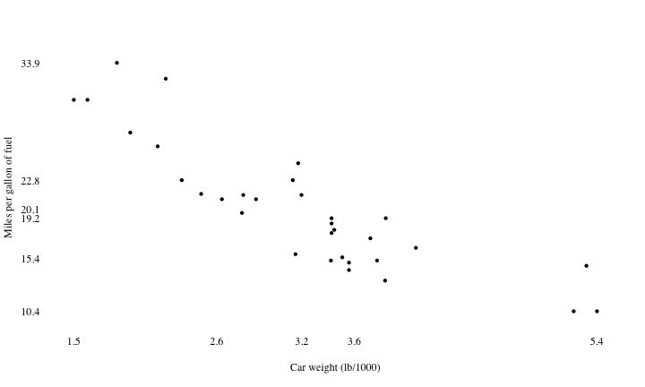

## Grammar of Graphics

## R data science packages

The `tidyverse` package

[figure not shown]

## The `ggplot2` package

Grammar of Graphics

- Build plots layer-by-layer

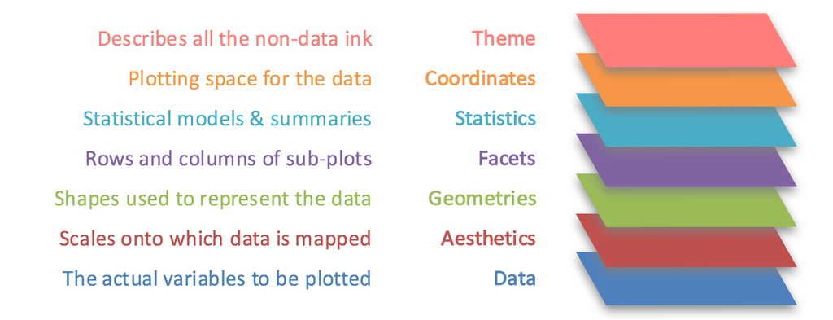

## Content of building blocks

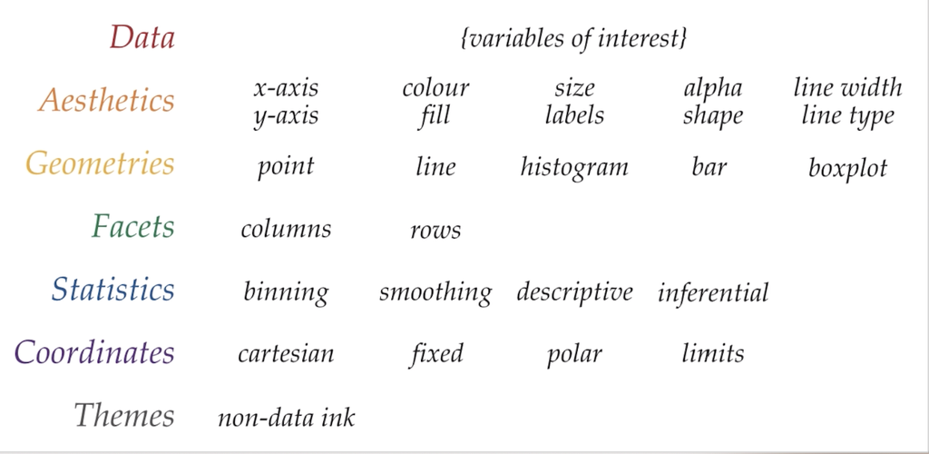

## Translation to aesthetics, geoms, etc.

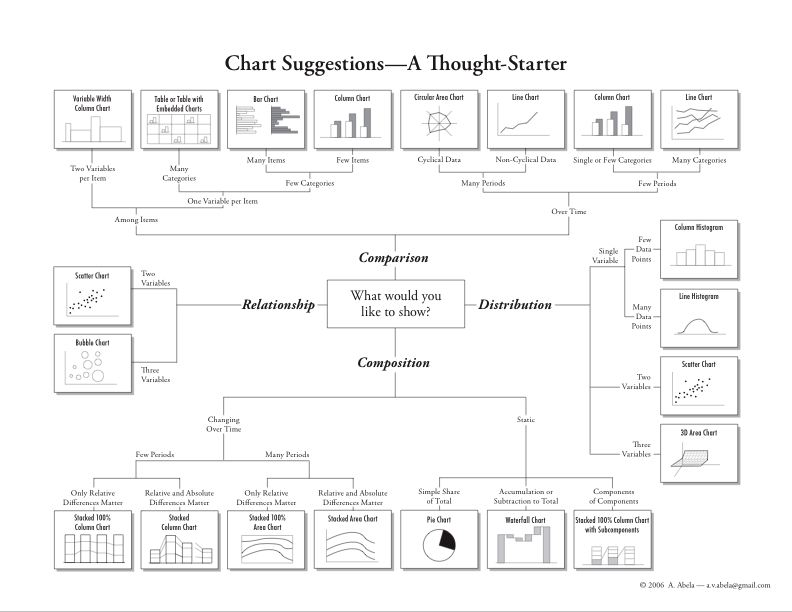

## Using `ggplot()`

## Data and aesthetics

The function `ggplot()` has two main arguments:

```r
ggplot(data = <data>, mapping = aes(x = <var>, y = <var>, ...))
```

- `<data>` name of the data set
- `mapping` maps variables to `aes`thetics (axis, color, group, etc.)

## Example

- `ggplot(mpg)` creates an empty plot array for data set `mpg`
- `aes(x = cty, y = displ)` maps variable values to axes

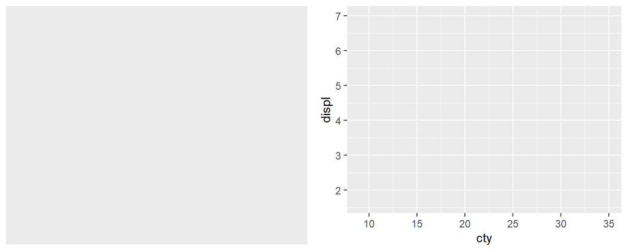

```r
grid.arrange(
  ggplot(mpg),
  ggplot(mpg, aes(x = cty, y = displ)),
nrow = 1)
```

## Geometrics

Geoms define shapes for representation (lines, points, bars, etc.)

- geoms are added with `+` sign
- multiple geoms can be added to same plot (e.g points and lines)

```r
ggplot(data = <data>, mapping = aes(x = <var>, y = <var>)) +
  geom_point() +
  geom_line()
```

## Example

Scatter plot plus regression line

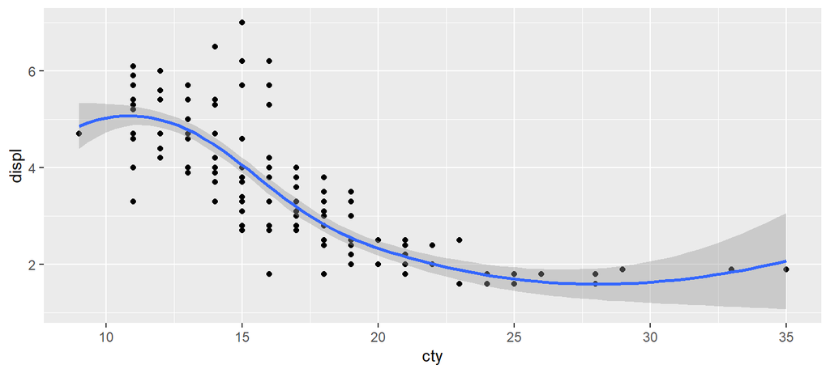

```r
ggplot(mpg, aes(x = cty, y = displ)) +
  geom_point() +
  geom_smooth()
```

## Another example

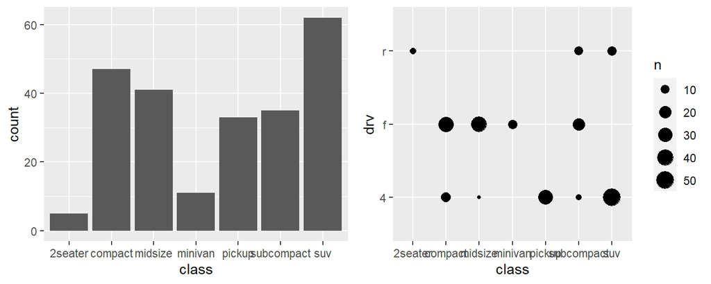

```r
grid.arrange(

  ggplot(mpg) +
    geom_bar(aes(class)),

  ggplot(mpg) +
    geom_count(aes(class, drv)),

  nrow = 1)
```

## Coordinates and scales

Flip the axis or transform the scales of the axes

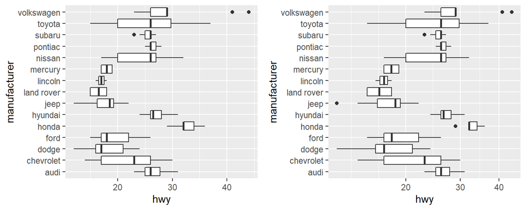

```r
grid.arrange(
  ggplot(mpg) + geom_boxplot(aes(manufacturer, hwy)) + coord_flip(),
  ggplot(mpg) + geom_boxplot(aes(manufacturer, hwy)) + coord_flip() +
    scale_y_log10(),
nrow = 1)
```

## Facets

Make separate plots for the levels of a categorical variable (`factor`)

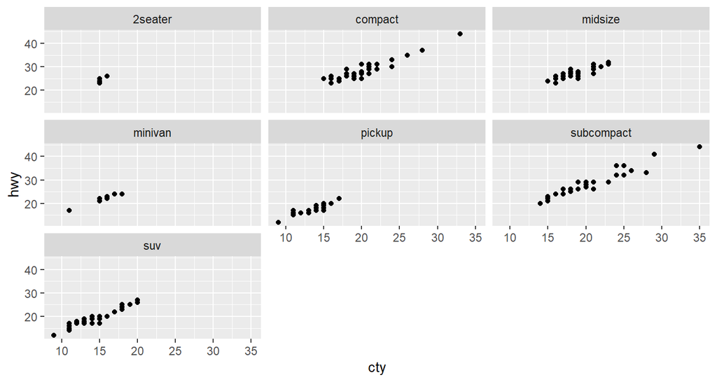

```r
ggplot(mpg, aes(x = cty, y = hwy)) +
  geom_point() +
  facet_wrap(vars(class))
```

## Themes

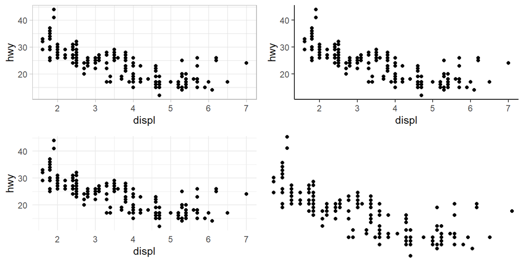

```r
grid.arrange(
  ggplot(mpg) + geom_point(aes(displ, hwy)) + theme_light(),
  ggplot(mpg) + geom_point(aes(displ, hwy)) + theme_classic(),
  ggplot(mpg) + geom_point(aes(displ, hwy)) + theme_minimal(),
  ggplot(mpg) + geom_point(aes(displ, hwy)) + theme_void(),
  nrow = 2)
```

## Preview lab 1A

1. Make plots with `ggplot2`
2. Combine aesthetics, geoms, facets, themes

\(~\)

Make the exercises in the R Markdown template

- Open template in RStudio and read the instructions
- Save the file in an appropriate folder
- Insert R code in the R chunks
- Run the chunks to test for errors
- Knit the HTML file when the code is error free